# Maintain your Brain, Secondary K10

## k10

- K10 score `CalcK10Score`

These results exclude those participants who were eligible for fewer than 2 modules but who were randomised. This results in N=6104.

Inference for differences in rc_trial_time trend by group_type_id for k10

## Data summary

```
## # A tibble: 8 x 5
## # Groups:   rc_trial_time [4]
##   rc_trial_time group_type_id  Mean    Sd N_obs
##           <int>         <int> <dbl> <dbl> <int>
## 1             1             1  12.6  3.27  3053
## 2             1             2  12.6  3.38  3051
## 3            10             1  12.8  3.55  2275
## 4            10             2  12.4  3.04  1599
## 5            11             1  12.9  3.62  2006
## 6            11             2  12.5  3.30  1417
## 7            12             1  12.8  3.80  2051
## 8            12             2  12.5  3.43  1432
```

## Results

```
##   response adjusted base_3yr_did    LCL    UCL  zstat     pz     Chisq p.value
## 1      k10       No       -0.323 -0.502 -0.144 -3.532 <0.001 30.633(3)  <0.001
## 2      k10      Yes       -0.309 -0.487 -0.130 -3.392 <0.001 29.395(3)  <0.001
```

NOTE: K10 is not baseline-standardised, so these results can be intepreted as:

group_type_id=2 showed a change of 0.323 *fewer* points (unadjusted) on the K10 score than group_type_id=1 from baseline to 3 years.

However, we can calculate an effect size from the raw difference in differences and pooled baseline SD:

$$ES = \frac{DID}{Baseline SD}$$
$$ES_{unadj} = \frac{abs(-0.323)}{3.327} =
0.097$$

$$ES_{adj} = \frac{abs(-0.309)}{3.327} =
0.093$$

So, the change from baseline to three years was 0.097 baseline SDs lower in group 2 than group 1 (unadjusted).

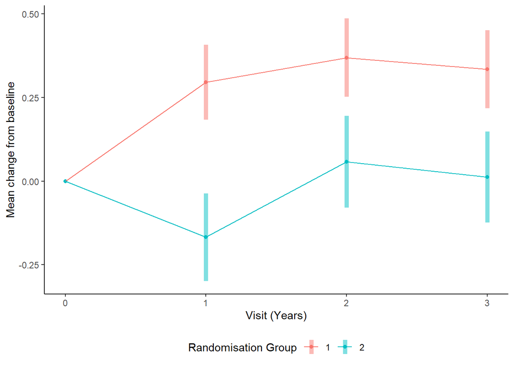

## Result

Covariates included in adjusted models:

- `myb_age`: Age at Baseline
- `myb_gender`: Reported gender
- `cl_edu_yrs`: Years of education
- `rcal_modules_sum`: Number of modules person was eligible for
- `adri_baseline`: ADRI at Baseline

A linear mixed model with a random effect for patient and fixed effects of time point, randomisation group and their interaction was run. An additional analysis including covariates of myb_age, myb_gender, cl_edu_yrs, rcal_modules_sum, adri_baseline was run. We report estimates of the group difference in the change from baseline to three years follow up with 95% confidence interval, and associated Z statistic and p-value. K10 score is *not* standardised at baseline, so the units are in raw K10 score units.

The unadjusted difference between randomisation groups of change from baseline to three year follow up was -0.323 ( 95%CI: -0.502- -0.144,Z=-3.532, p<0.001) .

The difference between randomisation groups of change from baseline to three year follow up was -0.309 ( 95%CI: -0.487 - -0.13,Z=-3.392,p<0.001), adjusting for myb_age, myb_gender, cl_edu_yrs, rcal_modules_sum, adri_baseline.

Analysis by Nancy Briggs and Gordana Popovic on 2024-02-14